## MA2102

# Probability and Statistics

#### Lecture-17(Part-a)

### Hyper Geometric Distribution:

Suppose a population consist of $N$ items in which $M$ are type-I and remaining $N-M$ are type-II. $n$ items are drawn at random from the population without replacement. Let $X$ denote the number of items of type-I in the selection.

$S_X=\{x:x\text{ is an integer and } max(0,n-(N-M))\le x \le min(M,n)\}$

$PMF:$ $p_X(x)=P(X=x)=\frac{\binom{M}{x}\binom{N-M}{n-x}}{\binom{N}{n}}$, $x\in S_X$

**Validity of PMF**

- $p_X(x)>0$ for $x\in S_X$
- $\sum_{x\in S_X}p_X(x)=\sum_{x\in S_X}\frac{\binom{M}{x}\binom{N-M}{n-x}}{\binom{N}{n}}=\frac{\sum_{x\in S_X}\binom{M}{x}\binom{N-M}{n-x}}{\binom{N}{n}}=\frac{\binom{N}{n}}{\binom{N}{n}}=1$ ($\because$ Vandermands identity)

Here $X$ is said to have **Hyper Geometric distribution** with parameters $N$(population size), $M$(type-I items), $n$(sample size)

**Notation:** $X\sim HypGeom(N,M,n)$

$E(X)=\frac{nM}{N}$, and $Var(X)=\frac{nM(N-M)(N-n)}{N^2(N-1)}$

**Capture-Recapture Method:** Suppose we want to estimate the fish population in certain lake, then we can do the following procedure.

Let $N$(Unknown) be the to total fish in a lake. First we capture $M$ fish from the lake, mark them and we release back to the lake (So these $M$ marked fish are our type-I). Next day we catch again $n$ fish at random locations of lake(so these $n$ fish is our sample)

let $k$= number of marked fish from the sample(second catch)

Here $N$ is unknown, and $M,n,k$ are known

Now, lake has two types of fish (marked fish(type-I) and unmarked fish(type-II))

Let $X$ denote the number of marked fish (type-I) in the sample(second catch)

then $X\sim HypGeom(N,M,n)$

so, $E(X)\approx k$ ($\because$ Expected number of marked fish in the sample should be approximately close to $k$)

$\frac{Mn}{N}\approx k$ $\Rightarrow$ $N\approx \frac{Mn}{k}$ ($\because$ $E(X)=\frac{nM}{N}$)

$\therefore$ Approximately lake will have $\frac{Mn}{k}$ fish.

### Poisson Process

We consider a event occurrences over a time(distance, area, or volume), happening under a **Poisson Process**, provided they satisfy the following assumptions(we state over time only).

i). The probability of single event occurrence during a small time interval is proportional to the length of time interval(area of region).

ii). The probability of more than one event occurrence during a small time interval is negligible

iii). The number of event occurrences during disjoint time intervals are independent

**Examples:**

1). Email occurrences on given day (over time)

2). Wrong telephone numbers that are dialed in a day (over time)

3). Misprints on a page of a book (over area)

4). People living more than 100 years in a community (over area)

5). Packages of dog biscuits sold in a particular store (over time)

6). Customer entering in a Post office/Bank/Shopping mall on a given day(over time)

### Poisson Distribution:

Consider Poisson process(over time)

Let $X=$ number of event occurrences in unit time interval $S_X=\{0,1,2,3,...\}$

Let the unit time interval be $[0,1]$

For large $n$, we divide interval $[0,1]$ into $n$ non-overlapping subintervals of equal length.

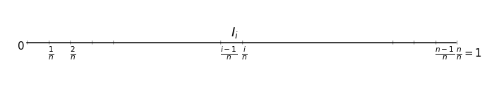

```python
import matplotlib.pyplot as plt
fig, ax = plt.subplots(figsize=(12,2))
ax.plot([-5,5],[0,0],color='black')
ax.text(-5.2,-0.01,"0",fontsize=15)
ax.text(-5,0,r"|",fontsize=5)
ax.text(-4.5,0,r"|",fontsize=5)
ax.text(-4.5,-0.02,r"$\frac{1}{n}$",fontsize=15)

ax.text(-4,0,r"|",fontsize=5)
ax.text(-4,-0.02,r"$\frac{2}{n}$",fontsize=15)

ax.text(-3.5,0,r"|",fontsize=5)
ax.text(-3,0,r"|",fontsize=5)


ax.text(-0.5,0,r"|",fontsize=5)
ax.text(-0.5,-0.02,r"$\frac{i-1}{n}$",fontsize=15)

ax.text(0,0,r"|",fontsize=5)
ax.text(0,-0.02,r"$\frac{i}{n}$",fontsize=15)

ax.text(-0.25,0.01,r"$I_i$",fontsize=18)


ax.text(3.5,0,r"|",fontsize=5)
ax.text(4,0,r"|",fontsize=5)

ax.text(4.5,0,r"|",fontsize=5)
ax.text(4.5,-0.02,r"$\frac{n-1}{n}$",fontsize=15)

ax.text(5,0,r"|",fontsize=5)
ax.text(5,-0.02,r"$\frac{n}{n}=1$",fontsize=15)

ax.axis('off')
plt.show()
```

Let $I_i=\left[\frac{i-1}{n},\frac{i}{n}\right]$, length($I_i$)=$\frac{1}{n}$ for $i=1,2,...n$

Probability of more than one occurrence during time interval $I_i$ is negligible [$\because$ length($I_i$) is small & by assumption (ii)] for $i=1,2,...n$

Therefore (for large $n$) there will be at most one event occurrence during the time interval $I_i$ for $i=1,2,...n$

In any subinterval there may be event occurrence(success) or not(failure), and probability of single event occurrence during small time interval is proportional to the length of interval (by assumption (i))

$\therefore$ $p$=P(success)=P(single event occurrence in $I_i$)=$\lambda$(length($I_i$))=$\lambda\left(\frac{1}{n}\right)=\frac{\lambda}{n}$

Here $\lambda$ is proportional constant, also called rate parameter

Observing if there is a event occurrence(success) in each subinterval $I_i$ for $i=1,2,...n$ is kind of like performing $n$ independent (by assumption(iii)),and identical Bernoulli trials with probability of success $p=\frac{\lambda}{n}$

$X\sim Bin(n,\frac{\lambda}{n})$

$PMF:$ $p_X(k)=P(X=k)=\binom{n}{k}\left(\frac{\lambda}{n}\right)^k\left(1-\frac{\lambda}{n}\right)^{n-k}$ $\to$ $\frac{e^{-\lambda}\lambda^k}{k!}$ as $n\to\infty$

$\therefore$ $p_X(k)=\frac{e^{-\lambda}\lambda^k}{k!}$, for $k=0,1,2,3,...$

Here $X$ is said to have **Poisson distribution** with rate parameter $\lambda$

**Validity of PMF:**

- $p_X(k)>0$ for $k=0,1,2,3,...$
- $\sum_{k=0}^{\infty}p_X(k)=\sum_{k=0}^{\infty}\frac{e^{-\lambda}\lambda^k}{k!}$=$e^{-\lambda}\sum_{k=0}^{\infty}\frac{{\lambda^k}}{k!}=e^{-\lambda}e^{\lambda}=1$

**Notation:** $X\sim Poisson(\lambda)$

$MGF:$ $M_X(t)=E(e^{tX})=\sum_{k=0}^{\infty}e^{tk}p_X(k)=\sum_{k=0}^{\infty}e^{tk}\frac{e^{-\lambda}\lambda^k}{k!}=e^{-\lambda}\sum_{k=0}^{\infty}\frac{{\left(\lambda e^{t}\right)}^k}{k!}=e^{-\lambda}e^{\lambda e^t}=e^{\lambda(e^t-1)}$

$E(X)=Var(X)=\lambda$

**Note:** Here the rate parameter $\lambda=$average number of event occurrence in unit time interval.

**Exercise:** Let $X\sim Poisson(\lambda)$. Show that $E(X)=Var(X)=\lambda$ through $MGF$ of $X$

$\left[ Hint:\mu=M_X^{(1)}(0),\sigma^2=M_X^{(2)}(0)-\left(M_X^{(1)}(0)\right)^2\right]$

```python
%matplotlib inline
import math
import numpy as np
import matplotlib.pyplot as plt
from ipywidgets import interact ,interactive, fixed, interact_manual
import ipywidgets as widgets

Infty=100
def poisson_pmf(lmda,k):
    if k>=0:
        return ((math.e**(-lmda))*lmda**k)/math.factorial(k)
    else:
        return 0

def poisson_cdf(lmda,x):
    s=0;
    for k in range(0,math.floor(x)+1):
        s+=poisson_pmf(lmda,k)
    return s
def poisson_pmf_vec(lmda):
    v=[]
    for k in range(0,Infty):
        v.append(poisson_pmf(lmda,k))
    return v

def poisson_bar(lmda):
    #fig, ax = plt.subplots()
    fig = plt.figure(figsize=(12,8))
    ax=fig.add_subplot(111)
    ax.bar(list(range(0,Infty)),poisson_pmf_vec(lmda))
    ax.set_title("Poisson Distribution")
    ax.set_xlabel("$trial$")
    ax.set_ylabel("$p_X(k)$")
    plt.show()


# Please Click the Run Interact Button to see the Bar graph
interactive(poisson_bar,{'manual':True},lmda=widgets.FloatSlider(min=1, max=20, step=0.5, value=2,description='$\lambda$:'))
```

**Example:** Customers arrive in a shopping mall at rate 5 per minute. What is the probability no customer arrive in 1 minute period.

*Solution:* Let $X=$ number of customer arrive at shopping mall in $1$ minute

$\lambda=5$ (rate parameter)

$\therefore$ $X\sim Poisson(\lambda)$, $p_X(k)=\frac{e^{-5}5^k}{k!}$, for $k=0,1,2,...$

$P(\text{no customer in one minute period})=P(X=0)=\frac{e^{-5}5^0}{0!}=e^{-5}=0.0067379$

**Example:** In a length manuscript, it is discovered that only $13.5\%$ of pages contain no typing errors. Find the percentage of pages that contain one error.

*Solution:* Let $X=$ number of typing errors in a page

then $X\sim Poisson(\lambda)$ $\Rightarrow$ $p_X(k)=\frac{e^{-\lambda}\lambda^k}{k!}$, for $k=0,1,2,..$

It is given that $P(X=0)=0.135$ $\Rightarrow$ $\frac{e^{-\lambda}\lambda^0}{0!}=0.135\Rightarrow e^{-\lambda}=0.135$

$\lambda=\log_e{\frac{1}{0.135}}=2.002481\approx 2$

Here we are interested in $P(X=1)=?$

$P(X=1)=\frac{e^{-2}2^1}{1!}=0.2706$

Hence 27 percent of pages contains exactly 1 error

**Problem:** Each of 500 soldiers in an army company independently has certain disease with probability $\frac{1}{1000}$. This disease will show up in a blood test, and to facilitate matters blood samples from all 500 are pooled and tested. What is (approximate) probability that the blood test will be positive.

*solution:* Each person may have disease(success) or not(failure)

$p=P(\text{success})=\frac{1}{1000}=0.001$

$X=$ number of soldiers who has disease among 500 soldiers

$X\sim Bin(500,0.001)$

blood test will be positive $\iff$ $X\ge 1$

Here we are interested in $P(X\ge 1)=?$

$P(X\ge 1)=1-P(X<1)=1-P(X=0)=1-\binom{500}{0}(0.001)^0(1-0.001)^{500}$

$=1-(0.999)^{500}=0.3936210551388153$

But above expression $1-(0.999)^{500}$ needs a lot of computation.

since $n=500$(large) & $p=0.001$ (small) & $np=\frac{1}{2}$(moderate size). So we can use Poisson approximation to Binomial distribution

i.e $\binom{n}{k}p^k(1-p)^{n-k}\approx \frac{e^{-\lambda}\lambda^k}{k!}$

$\therefore$ $P(X\ge 1)=1-P(X=0)=1-\frac{e^{-\frac{1}{2}}\left(\frac{1}{2}\right)^0}{0!}=0.3934693402873666$

As we can see that above approximation is quite good and does not need too much computation.